# Reproducible Research: Peer Assessment 1

## Loading and preprocessing the data

```r
mytable <- read.table("activity.csv", header = TRUE, sep = ",", stringsAsFactors = TRUE)
```

Here is a summary table

```r
library(knitr)
kable(summary(mytable))
```

|  | steps | date | interval |
| --- | --- | --- | --- |
|  | Min. : 0.00 | 2012-10-01: 288 | Min. : 0.0 |
|  | 1st Qu.: 0.00 | 2012-10-02: 288 | 1st Qu.: 588.8 |
|  | Median : 0.00 | 2012-10-03: 288 | Median :1177.5 |
|  | Mean : 37.38 | 2012-10-04: 288 | Mean :1177.5 |
|  | 3rd Qu.: 12.00 | 2012-10-05: 288 | 3rd Qu.:1766.2 |
|  | Max. :806.00 | 2012-10-06: 288 | Max. :2355.0 |
|  | NA’s :2304 | (Other) :15840 | NA |

## What is mean total number of steps taken per day?

I create a new dataframe variable called nonna without NAs. Here is a summary table

```r
nonna<-na.omit(mytable)
kable(summary(nonna))
```

|  | steps | date | interval |
| --- | --- | --- | --- |
|  | Min. : 0.00 | 2012-10-02: 288 | Min. : 0.0 |
|  | 1st Qu.: 0.00 | 2012-10-03: 288 | 1st Qu.: 588.8 |
|  | Median : 0.00 | 2012-10-04: 288 | Median :1177.5 |
|  | Mean : 37.38 | 2012-10-05: 288 | Mean :1177.5 |
|  | 3rd Qu.: 12.00 | 2012-10-06: 288 | 3rd Qu.:1766.2 |
|  | Max. :806.00 | 2012-10-07: 288 | Max. :2355.0 |
|  | NA | (Other) :13536 | NA |

Using dplyr package I calculate the total number of steps per day. Then a histogram is plotted

```r
library(dplyr)
```

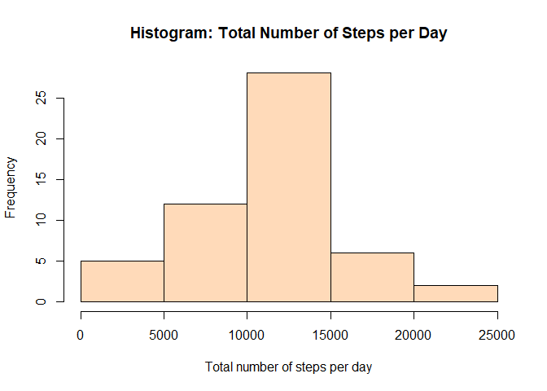

```r
steps_day <- nonna %>%
  group_by(date) %>%
  summarise(total=sum(steps), .groups= 'drop')

hist(steps_day$total,
     col = "peachpuff",
     border = "black",
     xlab = "Total number of steps per day",
     main = "Histogram: Total Number of Steps per Day")
```

Both measures are very close

```r
mymean <- mean(steps_day$total)
mymedian <- median(steps_day$total)
```

The mean of the total number of steps is 1.076618910^{4} and the median is 10765

## What is the average daily activity pattern?

Using dplyr package I calculate the mean of the number of steps taken. Then a line chart is plotted

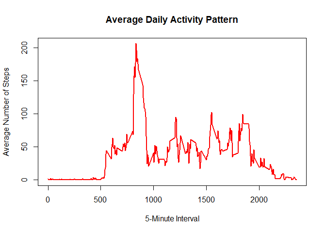

```r
steps_daily <- nonna %>%
  group_by(interval) %>%
  summarise(totalmean=mean(steps), .groups= 'drop')

plot(steps_daily$interval, steps_daily$totalmean, type = "l",
     col = 'red', lwd = 2,
     xlab = '5-Minute Interval', ylab = 'Average Number of Steps',
     main = 'Average Daily Activity Pattern')
```

Get the maximum number of steps from the 5-minute interval, on average across all the days in the dataset.

```r
maxmean <- max(steps_daily$totalmean)
maxinterval <- steps_daily$interval[which.max(steps_daily$totalmean)]
```

The maximum average number of steps is 206.1698113 in the interval 835.

## Imputing missing values

Get the total number of missing values in the dataset

```r
count_nas <- sum(is.na(mytable))
```

The total number of missing values is 2304.

The imputation strategy chosen is the one based on the mean for that 5-minute interval

```r
meanvalues <-  nonna %>%
  group_by(interval) %>%
  summarise(totalmean=mean(steps), .groups= 'drop')
idx <- which(is.na(mytable))
cpytable <- mytable
for (i in 1:length(idx)){
    valueimputed<-meanvalues$totalmean[meanvalues$interval==cpytable$interval[idx[i]]]
    cpytable$steps[idx[i]] <-valueimputed
}
```

Here is a summary of the filled dataset

```r
kable(summary(cpytable))
```

|  | steps | date | interval |
| --- | --- | --- | --- |
|  | Min. : 0.00 | 2012-10-01: 288 | Min. : 0.0 |
|  | 1st Qu.: 0.00 | 2012-10-02: 288 | 1st Qu.: 588.8 |
|  | Median : 0.00 | 2012-10-03: 288 | Median :1177.5 |
|  | Mean : 37.38 | 2012-10-04: 288 | Mean :1177.5 |
|  | 3rd Qu.: 27.00 | 2012-10-05: 288 | 3rd Qu.:1766.2 |
|  | Max. :806.00 | 2012-10-06: 288 | Max. :2355.0 |
|  | NA | (Other) :15840 | NA |

Here is the histogram from the filled dataset

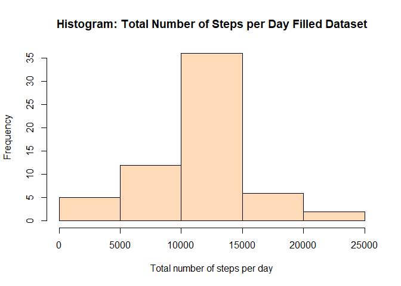

```r
steps_filled <- cpytable %>%
  group_by(date) %>%
  summarise(total=sum(steps), .groups= 'drop')

hist(steps_filled$total,
     col = "peachpuff",
     border = "black",
     xlab = "Total number of steps per day",
     main = "Histogram: Total Number of Steps per Day Filled Dataset")
```

```r
fillmymean <- mean(steps_filled$total)
fillmymedian <- median(steps_filled$total)
```

The mean and the median in the imputed dataset are the same 1.076618910^{4} and 1.076618910^{4}, respectively. Compared against the original dataset (no NA’s), the mean are the same (Original (No NA’s)=1.076618910^{4}, imputed = 1.076618910^{4}), but, the median is slightly different (Original (no NA’s) = 10765, Imputed = 1.076618910^{4})

## Are there differences in activity patterns between weekdays and weekends?

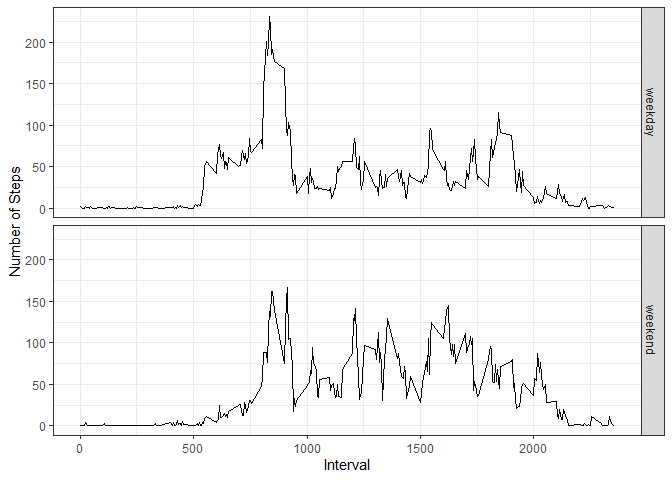

```r
cpytable$day<-c("Sunday", "Monday", "Tuesday", "Wednesday", "Thursday","Friday", "Saturday")[as.POSIXlt(cpytable$date)$wday + 1]

cpytable$day[cpytable$day %in% c("Saturday", "Sunday")]<-"weekend"
cpytable$day[cpytable$day != "weekend"] <- "weekday"
wkd_table <- cpytable %>% filter(day == "weekday")
wknd_table <- cpytable %>% filter(day == "weekend")

cpytable <- aggregate(steps ~ interval + day, data=cpytable, mean)

library(lattice)
library(ggplot2)

ggplot(cpytable, aes(interval, steps)) +
  geom_line() +
  facet_grid(day ~ .) +
  xlab("Interval") +
  ylab("Number of Steps")+theme_bw()
```